# Homework 2

Jaxon Lara

2024-09-19

```r
#Setup
library(ggplot2)

Leprosy <- read.csv('Homework2_leprosy.csv')
```

# **Introduction**

### This report will investigate the prevalence of leprosy in countries across the globe.

# **1.**

### India had the highest number of new leprosy cases in 2022 with 103,819 leprosy cases being recorded. However, it is not a fair comparison to to look at raw number of cases because the population of a country can drastically alter the perspective. A small country having an equal amount of leprosy cases to a large country would mean the smaller country has a larger percent of the population affected.

### This is also reinforced by the correlation value between a country’s population and number of new leprosy cases being 0.95.

```r
MostIndex <- which.max(Leprosy$New_Cases)
WhatMax <- Leprosy[MostIndex,]
WhatMax
```

```
##    Country Code       Region Population GDP_billions Land_Area New_Cases
## 76   India  IND Asia/Pacific 1399179585     3176.295   1147955    103819
```

# **2.**

```r
Leprosy$Per100k <- (Leprosy$New_Cases / Leprosy$Population) * 100000
lp_ggplot <- ggplot(Leprosy)
```

### The minimum percent of leprosy cases per 100k people was 0, the first quartile was 0, the median was 0.11, the third quartile was 1.04, and the max was 29.6.

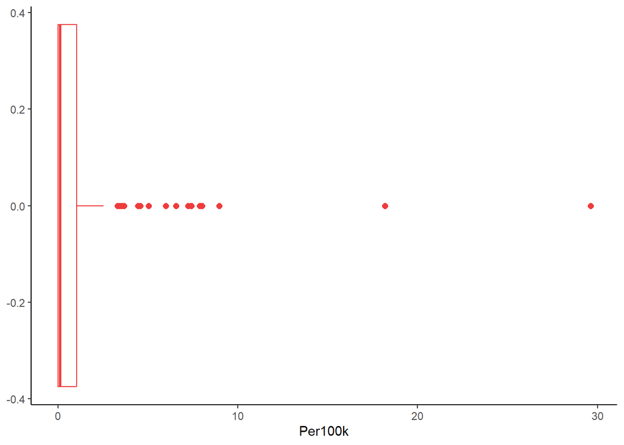

```r
lp_ggplot + geom_boxplot(aes(x=Per100k),outlier.shape=16,outlier.size=2,notch=FALSE,col='brown2', na.rm=TRUE) + theme_classic()
```

#### The graph represents the distribution of leprosy cases per 100k people in each country. May be interesting to note the minimum and first quartile overlap at 0 leprosy cases per 100k. The distribution is also heavily skewed right with many countries being outliers.

# **3.**

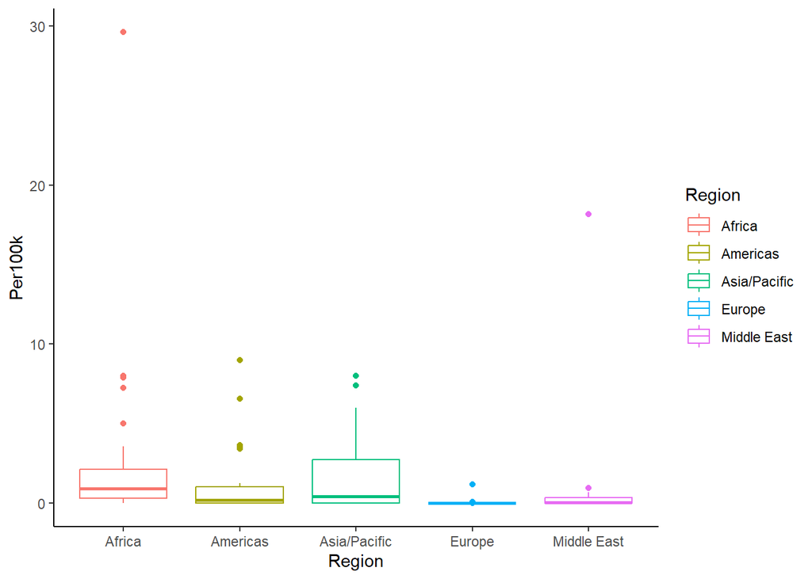

```r
ggplot(Leprosy, aes(x=Region, y=Per100k, color=Region)) + geom_boxplot(na.rm=TRUE) + theme_classic()
```

#### The graph shows the distribution of cases per 100k people in each country by region.

| Region | Number Of Districts | Median Cases Per 100K |
| --- | --- | --- |
| Africa | 45 | 0.91 |
| Americas | 34 | 0.21 |
| Asia/Pacific | 34 | 0.42 |
| Europe | 51 | 0 |
| Middle East | 20 | 0.05 |

# **4.**

### There is a negligible relationship between Leprosy cases per 100k people and GDP in billions because the correlation value between the 2 variables was calculated to be -0.02.

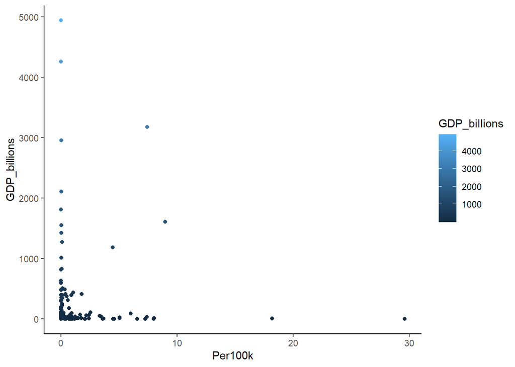

```r
Leprosy <- Leprosy[!is.na(Leprosy$GDP_billions),] #Removed problematic NA values for GDP_billions
ggplot(Leprosy, aes(x=Per100k, y=GDP_billions, color=GDP_billions)) + geom_point(na.rm=TRUE) + theme_classic()
```

#### The graph shows the relationship between a countries leprosy cases per 100k and the GPD in billions for the same country.

# **5.**

### In summary, the number of leprosy cases in a country correlates heavily with the population of that country. It is more valueable to analyze the leprosy cases per 100k for each country to determine the relative prevalence of leprosy in those countries. From this it was also determined that the Africa region, Asia/Pacific region, and the Americas region had the first, second, and third largest median leprosy cases per 100k respectively. Those 3 regions also had larger spreads of leprosy cases per 100k in their distributions. While Europe and the Middle East had the least median leprosy cases per 100k and had very small spreads in their distribution. It was also concluded that there is a negligible relationship between the GDP in billions of a country and its leprosy cases per 100k.

#### Go [here](https://www.internationalleprosyassociation.org) to learn more about this topic from the International Leprosy association.